```
From: https://github.com/ksatola
Version: 0.1.0
```

# Model - PM2.5 - Time Series Decomposition

## Contents

- Time series decomposition
- Load hourly data
- Load daily data
- Time Series Decomposition
  - The classical decomposition method
  - Seasonal-Trend decomposition using LOESS (STL)
  - Decomposition process for modelling
    - Detrending
    - Deseasonliting
    - Stationarity checking

```python
%load_ext autoreload
```

```python
%autoreload 2
```

```python
import sys
sys.path.insert(0, '../src')
```

```python
import warnings
warnings.filterwarnings('ignore')
warnings.simplefilter('ignore')
```

```python
import pandas as pd

import matplotlib.pyplot as plt
%matplotlib inline
```

```python
from model import (
    get_pm25_data_for_modelling,
)

from stats import (
    adfuller_test
)

from plot import (
    plot_stl,
    plot_decompose,
    plot_before_after,
    fit_theoretical_dist_and_plot
)
```

## Time Series Decomposition

`Time Series Decomposition` involves thinking of a series as a combination of level, trend, seasonality, and noise components. Decomposition provides a useful abstract model for thinking about time series generally and for better understanding problems during time series analysis and forecasting.

A useful abstraction for selecting forecasting methods is to break a time series down into systematic and unsystematic components:

- **Systematic:** Components of the time series that have consistency or recurrence and can be described and modeled.
- **Non-Systematic:** Components of the time series that cannot be directly modeled.

A given time series is thought to consist of three systematic components including level, trend, seasonality, and one non-systematic component called noise. These components are defined as follows:

- **Level:** The average value in the series.
- **Trend:** The increasing or decreasing value in the series.
- **Seasonality:** The repeating short-term cycle in the series.
- **Noise:** The random variation in the series.

A series is thought to be an aggregate or combination of these four components. All series have a level and noise. The trend and seasonality components are optional.

There are two types of time series composition, linear and nonlinear:

- **An additive model** is linear where changes over time are consistently made by the same amount. A linear trend is a straight line. A linear seasonality has the same frequency (width of cycles) and amplitude (height of cycles).
- **A multiplicative model** is nonlinear, such as quadratic or exponential. Changes increase or decrease over time. A nonlinear trend is a curved line. A nonlinear seasonality has an increasing or decreasing frequency and/or amplitude over time.

## Load hourly data

```python
dfh = get_pm25_data_for_modelling('ts', 'h')
dfh.head()
```

```
common.py | 42 | get_pm25_data_for_modelling | 08-Jun-20 18:05:08 | INFO: Dataframe loaded: /Users/ksatola/Documents/git/air-pollution/agh/data/dfpm25_2008-2018_hourly.hdf
common.py | 43 | get_pm25_data_for_modelling | 08-Jun-20 18:05:08 | INFO: Dataframe size: (96388, 1)
```

| Datetime | pm25 |
| --- | --- |
| 2008-01-01 01:00:00 | 92.0 |
| 2008-01-01 02:00:00 | 81.0 |
| 2008-01-01 03:00:00 | 73.0 |
| 2008-01-01 04:00:00 | 60.5 |
| 2008-01-01 05:00:00 | 61.0 |

```python
#dfh.tail(24)
```

```python
train_range_from_h = '2008-01-01 02:00:00'
train_range_to_h = '2018-12-30 23:00:00'
test_range_from_h = '2018-12-31 01:00:00'
test_range_to_h = None
```

## Load daily data

```python
dfd = get_pm25_data_for_modelling('ts', 'd')
dfd.head()
```

```
common.py | 42 | get_pm25_data_for_modelling | 08-Jun-20 18:05:10 | INFO: Dataframe loaded: /Users/ksatola/Documents/git/air-pollution/agh/data/dfpm25_2008-2018_daily.hdf
common.py | 43 | get_pm25_data_for_modelling | 08-Jun-20 18:05:10 | INFO: Dataframe size: (4019, 1)
```

| Datetime | pm25 |
| --- | --- |
| 2008-01-01 | 53.586957 |
| 2008-01-02 | 30.958333 |
| 2008-01-03 | 46.104167 |
| 2008-01-04 | 42.979167 |
| 2008-01-05 | 57.312500 |

```python
#dfd.tail(7)
```

```python
train_range_from_d = '2008-01-01'
train_range_to_d = '2018-12-25'
test_range_from_d = '2018-12-26'
test_range_to_d = None
```

## The classical decomposition method

### Hourly Frequency

```python
df = dfh.copy()
```

```python
# Work with different scope of PM2.5 observed (time series) data
series = df['pm25'] # hourly
#series = df['pm25'].resample(rule='D').mean() # daily
#series = df['pm25'].resample(rule='W').mean() # weekly
#series = df['pm25'].resample(rule='M').mean() # monthly
series.head()
```

```
Datetime
2008-01-01 01:00:00    92.0
2008-01-01 02:00:00    81.0
2008-01-01 03:00:00    73.0
2008-01-01 04:00:00    60.5
2008-01-01 05:00:00    61.0
Name: pm25, dtype: float64
```

```python
series.name
```

```
'pm25'
```

```python
series.index.freq
```

```python
# Different rolling window would be appropriate for different resamplings
rolling_window = 4 # for D
#rolling_window = 6 # for W
#rolling_window = 3 # for M
```

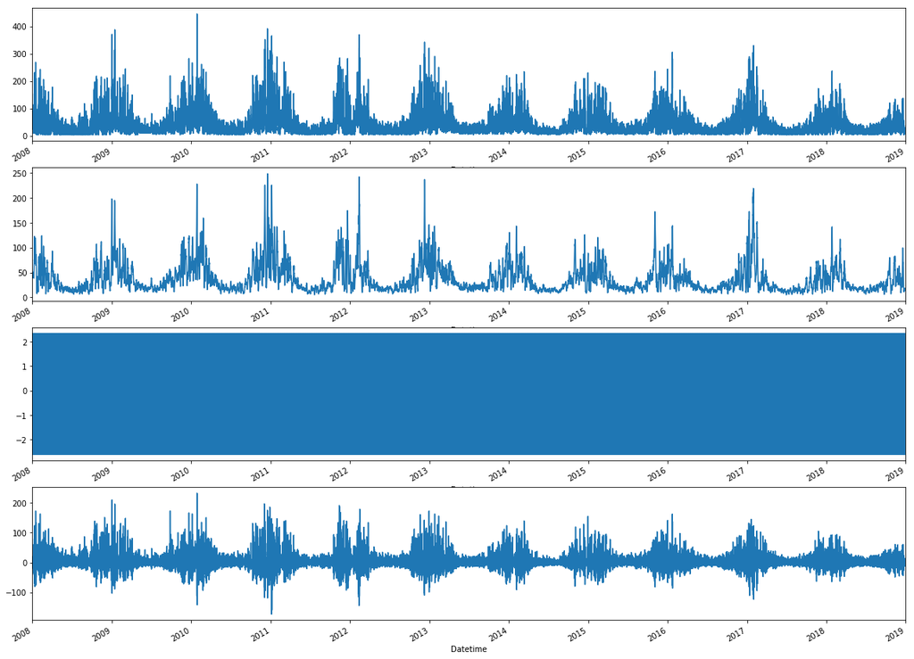

```
<statsmodels.tsa.seasonal.DecomposeResult at 0x12bae45d0>
```

```python
plot_decompose(data=series)
```

### Daily Frequency

```python
df = dfd.copy()
```

```python
# Work with different scope of PM2.5 observed (time series) data
#series = df['pm25'] # hourly
series = df['pm25'].resample(rule='D').mean() # daily
#series = df['pm25'].resample(rule='W').mean() # weekly
#series = df['pm25'].resample(rule='M').mean() # monthly
series.head()
```

```
Datetime
2008-01-01    53.586957
2008-01-02    30.958333
2008-01-03    46.104167
2008-01-04    42.979167
2008-01-05    57.312500
Freq: D, Name: pm25, dtype: float64
```

```python
series.index.freq
```

```
<Day>
```

```python
# Different rolling window would be appropriate for different resamplings
rolling_window = 4 # for D
#rolling_window = 6 # for W
#rolling_window = 3 # for M
```

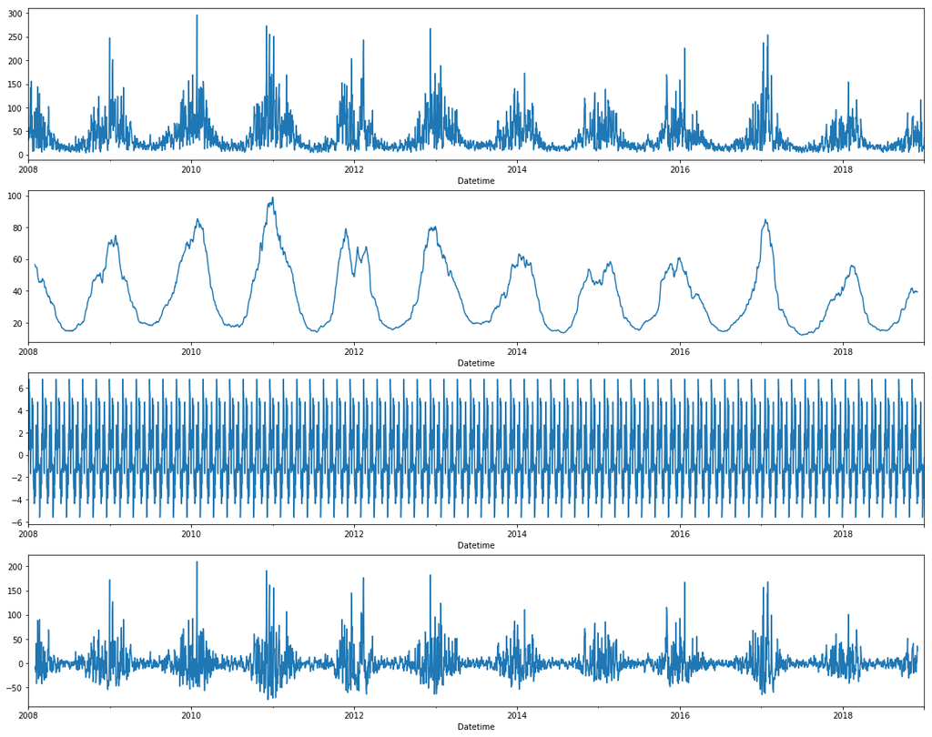

```
<statsmodels.tsa.seasonal.DecomposeResult at 0x12cd506d0>
```

```python
plot_decompose(data=series)
```

## Seasonal-Trend decomposition using LOESS (STL)

STL uses LOESS (locally estimated scatterplot smoothing) to extract smooths estimates of the three components. The key inputs into STL are:

- **seasonal** - The length of the seasonal smoother. Must be odd.
- **trend** - The length of the trend smoother, usually around 150% of seasonal. Must be odd and larger than seasonal.
- **low_pass** - The length of the low-pass estimation window, usually the smallest odd number larger than the periodicity of the data.

https://www.statsmodels.org/dev/examples/notebooks/generated/stl_decomposition.html

### Hourly Frequency

```python
df = dfh.copy()
```

```python
# Work with different scope of PM2.5 observed (time series) data
series = df['pm25'] # hourly
#series = df['pm25'].resample(rule='D').mean() # daily
#series = df['pm25'].resample(rule='W').mean() # weekly
#series = df['pm25'].resample(rule='M').mean() # monthly
series.head()
```

```
Datetime
2008-01-01 01:00:00    92.0
2008-01-01 02:00:00    81.0
2008-01-01 03:00:00    73.0
2008-01-01 04:00:00    60.5
2008-01-01 05:00:00    61.0
Name: pm25, dtype: float64
```

```python
# Different rolling window would be appropriate for different resamplings
rolling_window = 4 # for D
#rolling_window = 6 # for W
#rolling_window = 3 # for M
```

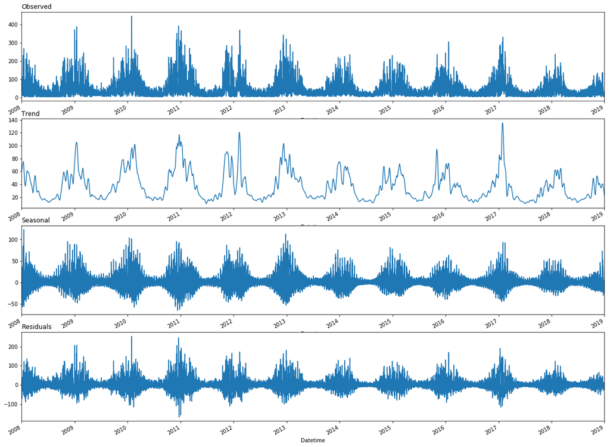

```
<statsmodels.tsa.seasonal.DecomposeResult at 0x1317aeb50>
```

```python
plot_stl(data=series, period=365, low_pass=367)
```

### Daily Frequency

```python
df = dfd.copy()
```

```python
# Work with different scope of PM2.5 observed (time series) data
#series = df['pm25'] # hourly
series = df['pm25'].resample(rule='D').mean() # daily
#series = df['pm25'].resample(rule='W').mean() # weekly
#series = df['pm25'].resample(rule='M').mean() # monthly
series.head()
```

```
Datetime
2008-01-01    53.586957
2008-01-02    30.958333
2008-01-03    46.104167
2008-01-04    42.979167
2008-01-05    57.312500
Freq: D, Name: pm25, dtype: float64
```

```python
# Different rolling window would be appropriate for different resamplings
rolling_window = 4 # for D
#rolling_window = 6 # for W
#rolling_window = 3 # for M
```

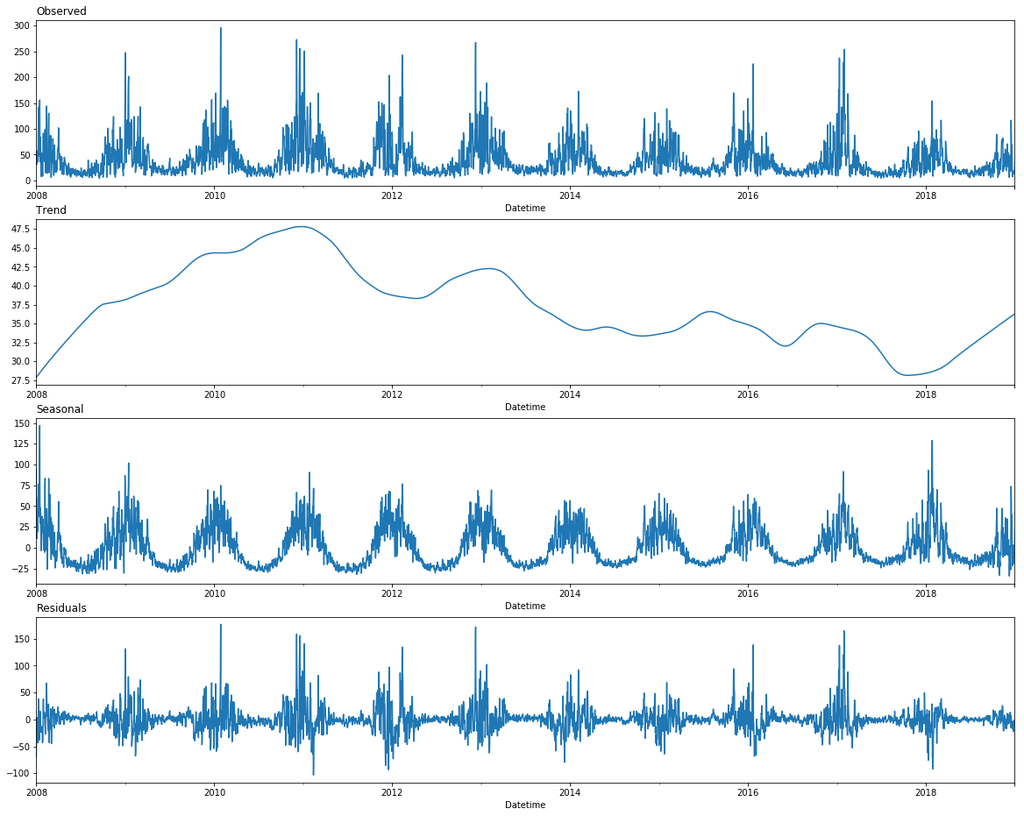

```
<statsmodels.tsa.seasonal.DecomposeResult at 0x1362c83d0>
```

```python
plot_stl(data=series, period=365)
```

## Decomposition process for modelling

Here, choose the decomposition method to move forward and the dataset (hourly, daily).

For the `clasical modelling`, we will focus on `residuals`, as they should be `stationary` (still to be confirmed below).

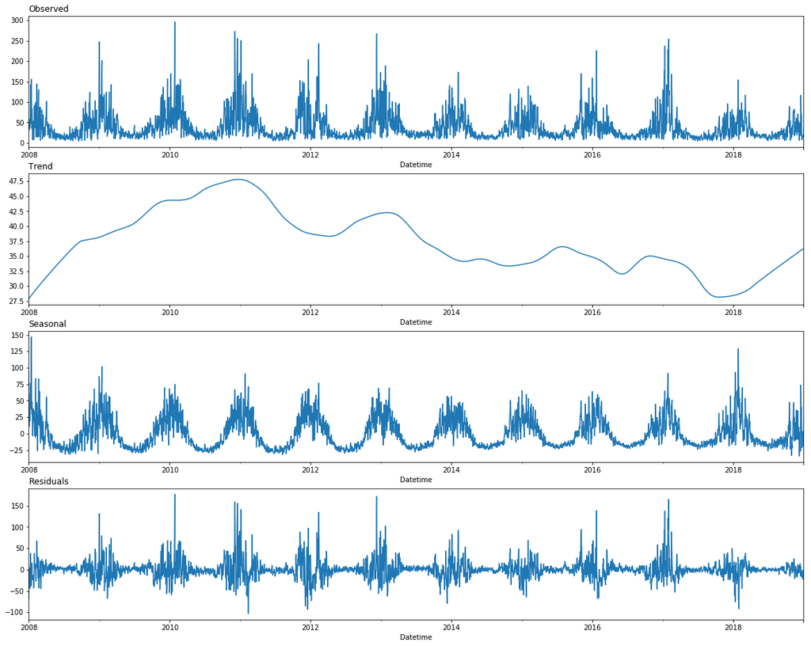

```python
# STL for Daily Data
result = plot_stl(data=dfd['pm25'], period=365, low_pass=367)
```

### Observed data

```python
result.observed[:5]
```

```
Datetime
2008-01-01    53.586957
2008-01-02    30.958333
2008-01-03    46.104167
2008-01-04    42.979167
2008-01-05    57.312500
Freq: D, Name: pm25, dtype: float64
```

### Use and remove trend

Our time series may contain a trend. A `trend` is a continued increase or decrease in the series over time.

Identifying and understanding `trend` information can aid in improving model performance; below are a few reasons:

- **Faster Modeling:** Perhaps the knowledge of a trend or lack of a trend can suggest methods and make model selection and evaluation more efficient.
- **Simpler Problem:** Perhaps we can correct or remove the trend to simplify modeling and improve model performance.
- **More Data:** Perhaps we can use trend information, directly or as a summary, to provide additional information to the model and improve model performance.

A time series with a trend is called `trend non-stationary`. An identified trend can be modeled. Once modeled, it can be removed from the time series dataset. This is called `detrending` the time series. If a dataset does not have a trend or we successfully remove the trend, the dataset is said to be `trend stationary`.

Specifically, a `trend` can be removed from your time series data (and data in the future) as a data preparation and cleaning exercise. This is common when using statistical methods for time series forecasting, but does not always improve results when using machine learning models. Alternately, a trend can be added, either directly or as a summary, as a new input variable to the supervised learning problem to predict the output variable.

Perhaps the simplest method to detrend a time series is by `differencing`. Specifically, a new series is constructed where the value at the current time step is calculated as the difference between the original observation and the observation at the previous time step.

```python
result.trend[:5]
```

```
Datetime
2008-01-01    27.904629
2008-01-02    27.947183
2008-01-03    27.989668
2008-01-04    28.032084
2008-01-05    28.074429
Freq: D, Name: trend, dtype: float64
```

```python
# Detrend a time series using differencing
series = result.observed
X = series.values
diff = list()
for i in range(1, len(X)):
    value = X[i] - X[i - 1]
    diff.append(value)
diff = pd.Series(diff, index=result.observed.index[1:])
```

Because no difference value can be created for the first observation (there is nothing for it to be subtracted from), the new dataset contains one less record. This approach works well for data with a linear trend. If the trend is quadratic (the change in the trend also increases or decreases), then a difference of the already-differenced dataset can be taken, a `second level of differencing`.

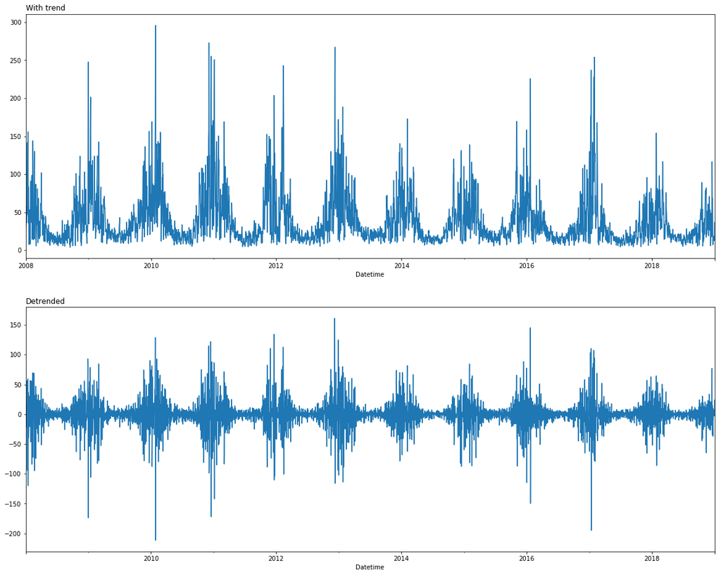

```python
plot_before_after(result.observed, diff, "With trend", "Detrended")
```

```python
# Use a linear model to detrend a time series
from sklearn.linear_model import LinearRegression
import numpy as np

series = result.observed

# Create integer-indexed observations
X = [i for i in range(0, len(series))]
X = np.reshape(X, (len(X), 1))
print(X[:5])

y = series.values
print(y[:5])

# Fit linear model
model = LinearRegression()
model.fit(X, y)

# Calculate trend
trend1 = model.predict(X)
print(trend1[:5])

# Detrend
detrended = [y[i] - trend1[i] for i in range(0, len(series))]
print(detrended[:5])
```

```
[[0]
 [1]
 [2]
 [3]
 [4]]
[53.58695652 30.95833333 46.10416667 42.97916667 57.3125    ]
[43.97819481 43.97481936 43.97144391 43.96806846 43.96469301]
[9.608761707709753, -13.016486028819504, 2.132722756390365, -0.9889017917330918, 13.347806993476787]
```

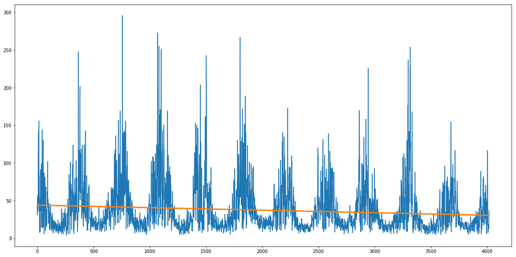

```python
# Plot trend
plt.figure(figsize=(20, 10))
plt.plot(y)
plt.plot(trend1, linewidth=3)
plt.show();
```

```python
# Check what is the trend line now
model.fit(X, detrended)

# Calculate trend (should be 0 now, flat horizontal line)
trend2 = model.predict(X)
print(trend2[:5])
```

```
[-4.50655520e-16 -4.52346124e-16 -4.54036728e-16 -4.55727332e-16
 -4.57417936e-16]
```

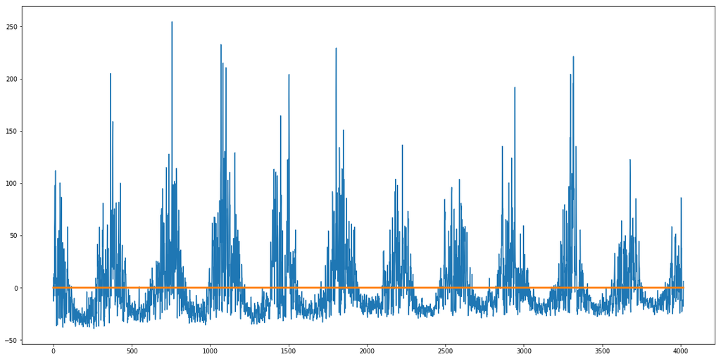

```python
# Plot detrended
plt.figure(figsize=(20, 10))
plt.plot(detrended)
plt.plot(trend2, linewidth=3)
plt.show();
```

[output not shown]

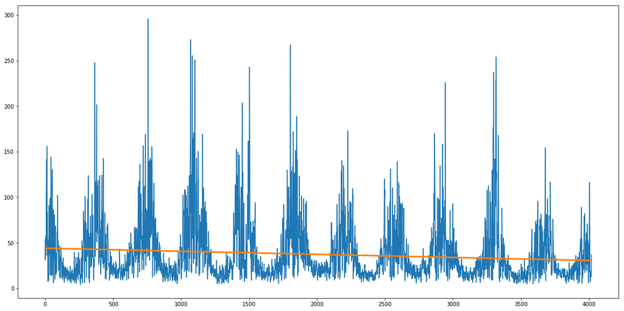

```python
# Check what is the trend line now
model.fit(X, detrended+trend1)

# Calculate trend (should be back as at the beginning)
trend3 = model.predict(X)
print(trend3[:5])

# Plot detrended
plt.figure(figsize=(20, 10))
plt.plot(y)
plt.plot(trend3, linewidth=3)
plt.show();
```

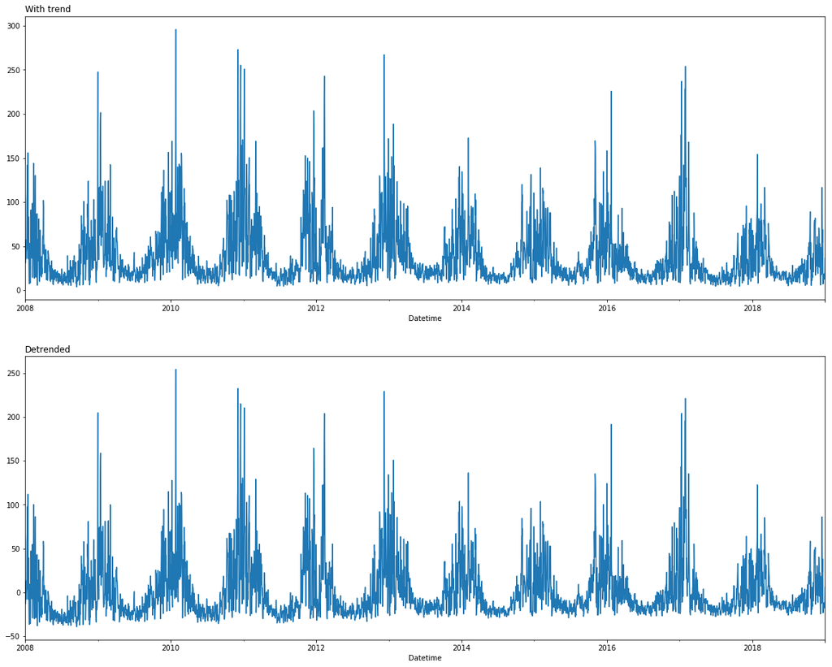

```python
y = pd.Series(y, index=result.observed.index)
detrended = pd.Series(detrended, index=result.observed.index)
plot_before_after(y, detrended, "With trend", "Detrended")
```

### Use and remove seasonality

Time series datasets can contain a `seasonal component`. This is a cycle that repeats over time, such as monthly or yearly. This repeating cycle may obscure the signal that we wish to model when forecasting, and in turn may provide a strong signal to our predictive models.

`Seasonal variation`, or `seasonality`, are cycles that repeat regularly over time. A cycle structure in a time series may or may not be seasonal. If it consistently repeats at the same frequency, it is seasonal, otherwise it is not seasonal and is called a `cycle`.

Understanding the seasonal component in time series can improve the performance of modeling with machine learning. This can happen in two main ways:

- **Clearer Signal:** Identifying and removing the seasonal component from the time series can result in a clearer relationship between input and output variables.
- **More Information:** Additional information about the seasonal component of the time series can provide new information to improve model performance.

Modeling seasonality and removing it from the time series may occur during data cleaning and preparation. Extracting seasonal information and providing it as input features, either directly or in summary form, may occur during feature extraction and feature engineering activities.

The simplest approach to determining if there is an aspect of seasonality is to plot and review your data, perhaps at different scales and with the addition of trend lines.

Once seasonality is identified, it can be modeled. The model of seasonality can be removed from the time series. This process is called `Seasonal Adjustment`, or `Deseasonalizing`. A time series where the seasonal component has been removed is called `seasonal stationary`. A time series with a clear seasonal component is referred to as `seasonal non-stationary`.

As we are primarily interested in predictive modeling and time series forecasting, we are limited to methods that can be developed on historical data and available when making predictions on new data.

A simple way to correct for a seasonal component is to use `differencing`. If there is a seasonal component at the level of one week, then we can remove it on an observation today by subtracting the value from last week.

```python
result.seasonal[:5]
```

```
Datetime
2008-01-01    94.496364
2008-01-02    14.806637
2008-01-03    16.350060
2008-01-04    11.232492
2008-01-05    27.397082
Freq: D, Name: season, dtype: float64
```

```python
# Deseasonalize a time series using differencing

series = result.observed
X = series.values
print(X[:5])

diff = []
days_in_year = 365

for i in range(days_in_year, len(X)):
    value = X[i] - X[i - days_in_year]
    diff.append(value)
diff = pd.Series(diff, index=result.observed.index[365:])
```

```
[53.58695652 30.95833333 46.10416667 42.97916667 57.3125    ]
```

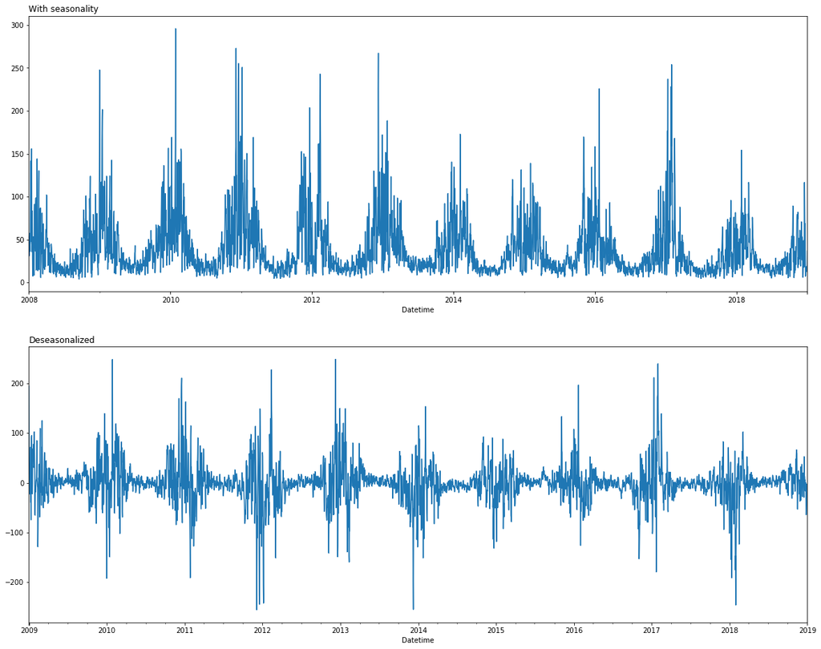

```python
plot_before_after(result.observed, diff, "With seasonality", "Deseasonalized")
```

We can model the seasonal component directly, then subtract it from the observations. The seasonal component in a given time series is likely a sine wave over a generally fixed period and amplitude. This can be approximated easily using a curve-fitting method.

```python
# Model seasonality with a polynomial model
from numpy import polyfit

series = result.observed

X = [i%365 for i in range(0, len(series))]
print(X[:5])

y = series.values
print(y[:5])

# Fit polynomial: x^2*b1 + x*b2 + ... + bn
degree = 4
coef = polyfit(X, y, degree)
print('Coefficients: %s' % coef)

# Create curve
curve = []
for i in range(len(X)):
    value = coef[-1]
    for d in range(degree):
        value += X[i]**(degree-d) * coef[d]
    curve.append(value)
```

```
[0, 1, 2, 3, 4]
[53.58695652 30.95833333 46.10416667 42.97916667 57.3125    ]
Coefficients: [-5.24747614e-08  3.88570661e-05 -7.53229315e-03  1.02827324e-01
  6.67842463e+01]
```

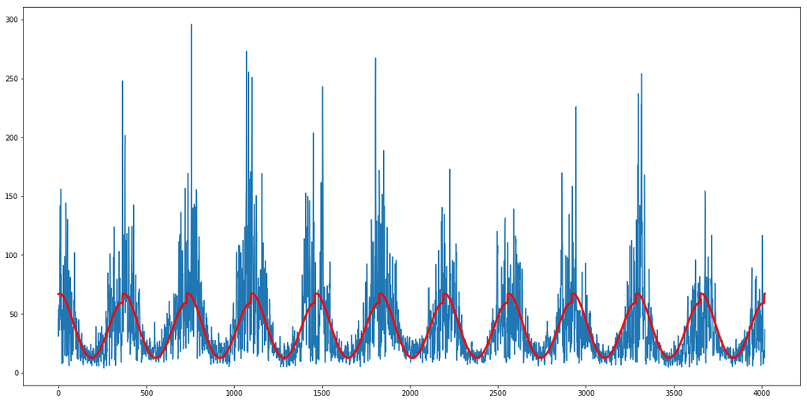

```python
# Plot curve over original data
plt.figure(figsize=(20, 10))
plt.plot(series.values)
plt.plot(curve, color='red', linewidth=3)
plt.show();
```

One limitation of this model is that it does not take into account of leap days, adding small offset noise that could easily be corrected with an update to the approach. For example, we could just remove the February 29 observations from the dataset when creating the seasonal model.

### Stationarity

**Time series is different from more traditional classification and regression predictive modeling problems. The temporal structure adds an order to the observations.** This imposes that important assumptions about the consistency of those observations needs to be handled specifically. For example, when modeling, there are assumptions that the summary statistics of observations are consistent. In time series terminology, we refer to this expectation as the time series being `stationary`. These assumptions can be easily violated in time series by the addition of a trend, seasonality, and other time-dependent structures.

The observations in a `stationary time series` are not dependent on time. Time series are `stationary` if they do not have trend or seasonal effects. Summary statistics calculated on the time series are consistent over time, like the mean or the variance of the observations. When a time series is stationary, it can be easier to model. Statistical modeling methods assume or require the time series to be stationary to be effective.

Observations from a `non-stationary time series` show seasonal effects, trends, and other structures that depend on the time index. Summary statistics like the mean and variance do change over time, providing a drift in the concepts a model may try to capture. Classical time series analysis and forecasting methods are concerned with making non-stationary time series data stationary by identifying and removing trends and removing seasonal effects.

There are some finer-grained notions of stationarity that you may come across if you dive deeper into this topic. They are:

- **Stationary Process:** A process that generates a stationary series of observations.
- **Stationary Model:** A model that describes a stationary series of observations.
- **Trend Stationary:** A time series that does not exhibit a trend.
- **Seasonal Stationary:** A time series that does not exhibit seasonality.
- **Strictly Stationary:** A mathematical definition of a stationary process, specifically that the joint distribution of observations is invariant to time shift.

There are many methods to check whether a time series (direct observations, residuals, otherwise) is stationary or non-stationary:

- **Look at plots:** You can review a time series plot of your data and visually check if there are any obvious trends or seasonality.
- **Summary statistics:** You can review the summary statistics for your data for seasons or random partitions and check for obvious or significant differences.
- **Statistical tests:** You can use statistical tests to check if the expectations of stationarity are met or have been violated.

You should make your time series stationary. If you have clear trend and seasonality in your time series, then model these components, remove them from observations, then train models on the residuals.

`Statistical time series methods` and even modern machine learning methods will benefit from the clearer signal in the data. But we should turn to machine learning methods when the classical methods fail. When we want more or better results. We cannot know how to best model unknown nonlinear relationships in time series data and some methods may result in better performance when working with non-stationary observations or some mixture of stationary and non-stationary views of the problem.

```python
result.resid[:5]
```

```
Datetime
2008-01-01   -68.814036
2008-01-02   -11.795487
2008-01-03     1.764438
2008-01-04     3.714591
2008-01-05     1.840989
Freq: D, Name: resid, dtype: float64
```

#### Look at Plots

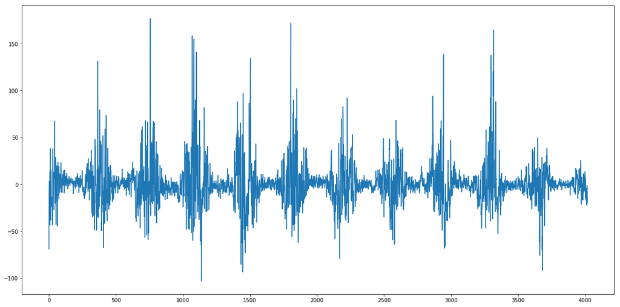

```python
series = result.resid

# Plot
plt.figure(figsize=(20, 10))
plt.plot(series.values)
plt.show();
```

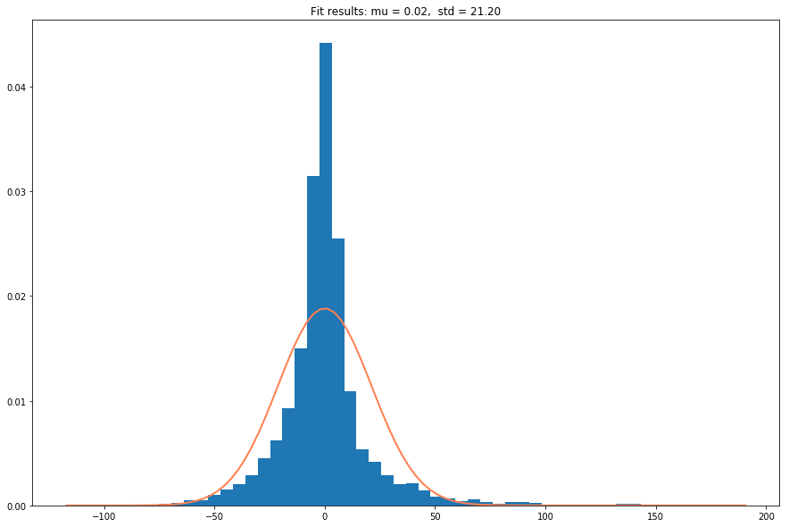

```python
# Fit theoretical distribution
fit_theoretical_dist_and_plot(series)
```

Skewed data is common in data science; `skew` is the degree of distortion from a normal distribution.

**Why do we care if the data is skewed?** If the response variable is `skewed`, the model will be trained on a much larger number of moderately values, and will be less likely to successfully predict the value for the most extreme values. The concept is the same as training a model on imbalanced categorical classes. If the values of a certain independent variable (feature) are skewed, depending on the model, skewness may violate model assumptions (e.g. logistic regression) or may impair the interpretation of `feature importance`.

```python
# select only continuous variables (for multicolumn dfs)
#cols = df_observed.dtypes[df_observed.dtypes != 'object'].index
#skewed = df_observed[cols].skew().sort_values(ascending=False)

skewed_features = series.to_frame().skew().sort_values(ascending=False)
skewness = pd.DataFrame({'Skew':skewed_features})
skewness
```

|  | Skew |
| --- | --- |
| resid | 1.540904 |